# Import libraries & dataframes

```python
# import libraries
import pandas as pd
import numpy as np
import os
import matplotlib.pyplot as plt
from matplotlib.ticker import MaxNLocator
import plotly.express as px
from scipy.stats import ttest_ind
from scipy.stats import ttest_1samp
import seaborn as sns
```

```python
path = r'C:\Users\muril\Data Analysis Projects\07-2023 Instacart Basket Analysis\02 Data'
```

```python
# import dataframe
df_high = pd.read_csv(os.path.join(path,'Prepared Data','high_activity_customers.csv'), index_col=0)
df_spend = pd.read_csv(os.path.join(path,'Prepared Data','profiling.csv'), index_col=0)
```

```python
df_dept = pd.read_csv(os.path.join(path,'Prepared Data','departments_cleaned.csv'))
```

```python
df_dept
```

|  | department_id | department |
| --- | --- | --- |
| 0 | 1 | frozen |
| 1 | 2 | other |
| 2 | 3 | bakery |
| 3 | 4 | produce |
| 4 | 5 | alcohol |
| 5 | 6 | international |
| 6 | 7 | beverages |
| 7 | 8 | pets |
| 8 | 9 | dry goods |
| 9 | 10 | bulk |
| 10 | 11 | personal care |
| 11 | 12 | meat seafood |
| 12 | 13 | pantry |
| 13 | 14 | breakfast |
| 14 | 15 | canned goods |
| 15 | 16 | dairy |
| 16 | 17 | household |
| 17 | 18 | babies |
| 18 | 19 | snacks |
| 19 | 20 | deli |
| 20 | 21 | missing |

```python
# merge dataframes
df_high = df_high.merge(df_spend.drop('region',axis=1), on='user_id', how='left')
```

```python
df_high.columns
```

```
Index(['order_id', 'user_id', 'order_number', 'order_day_of_week',
       'order_hour_of_day', 'days_since_prior_order', 'product_id',
       'add_to_cart_order', 'reordered', 'product_name', 'aisle_id',
       'department_id', 'prices', 'sex', 'state', 'age', 'date_joined',
       'n_dependents', 'family_status', 'income', 'region',
       'number_of_orders_x', 'profile_x', 'total_spending', 'days_as_customer',
       'weekly_spending', 'profile_y', 'number_of_orders_y', 'weekly_orders',
       'avg_order_frequency'],
      dtype='object')
```

```python
# df_high has duplicate columns for profile and number_of_orders (counts match) those columns can be dropped and renamed
df_high.rename(columns = {'profile_x' : 'profile'}, inplace = True)
df_high.rename(columns = {'number_of_orders_x' : 'number_of_orders'}, inplace = True)
df_high = df_high.drop(columns = ['profile_y'])
df_high = df_high.drop(columns = ['number_of_orders_y'])
```

#### 7.2.2 Spending analysis

```python
df_spend.describe()
```

|  | user_id | total_spending | days_as_customer | weekly_spending | number_of_orders | weekly_orders | avg_order_frequency |
| --- | --- | --- | --- | --- | --- | --- | --- |
| count | 162632.000000 | 162632.000000 | 162632.000000 | 162632.000000 | 162632.000000 | 162632.000000 | 162632.000000 |
| mean | 103082.527080 | 1485.505198 | 185.317410 | 54.964817 | 18.843407 | 0.710733 | 1.794000 |
| std | 59529.078801 | 1704.197567 | 96.802125 | 49.210473 | 17.365525 | 0.507387 | 0.753376 |
| min | 1.000000 | 5.000000 | 0.000000 | 0.368421 | 5.000000 | 0.260135 | 0.023810 |
| 25% | 51579.750000 | 454.500000 | 104.000000 | 24.865503 | 7.000000 | 0.424242 | 1.187500 |
| 50% | 103058.500000 | 888.200000 | 170.000000 | 42.520538 | 12.000000 | 0.571429 | 1.750000 |
| 75% | 154644.250000 | 1821.600000 | 266.000000 | 70.298280 | 23.000000 | 0.842105 | 2.357143 |
| max | 206209.000000 | 26651.100000 | 365.000000 | 2761.943902 | 99.000000 | 42.000000 | 3.844156 |

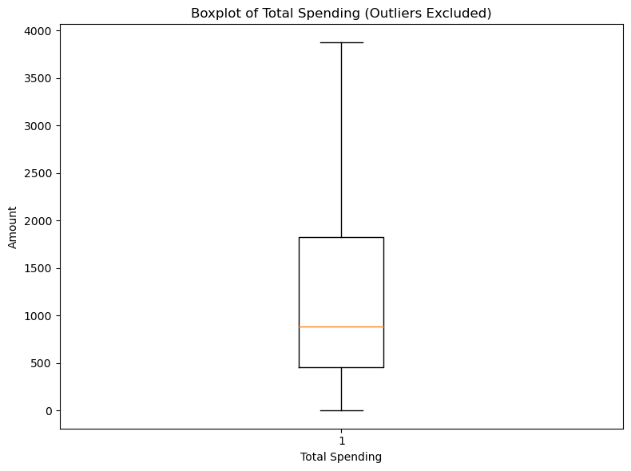

```python
# Create the boxplot for total spending per customer and exclude outliers
plt.figure(figsize=(8, 6))  # Set the figure size (optional)

# Assuming 'total_spending' is the column name in df_spend
plt.boxplot(df_spend['total_spending'], showfliers=False)

# Add labels and title
plt.xlabel('Total Spending')
plt.ylabel('Amount')
plt.title('Boxplot of Total Spending (Outliers Excluded)')


# Adjust margins and spacing
plt.tight_layout()

# export chart
plt.savefig('total_spending_per_customer_xoutliers.png')

plt.show()
```

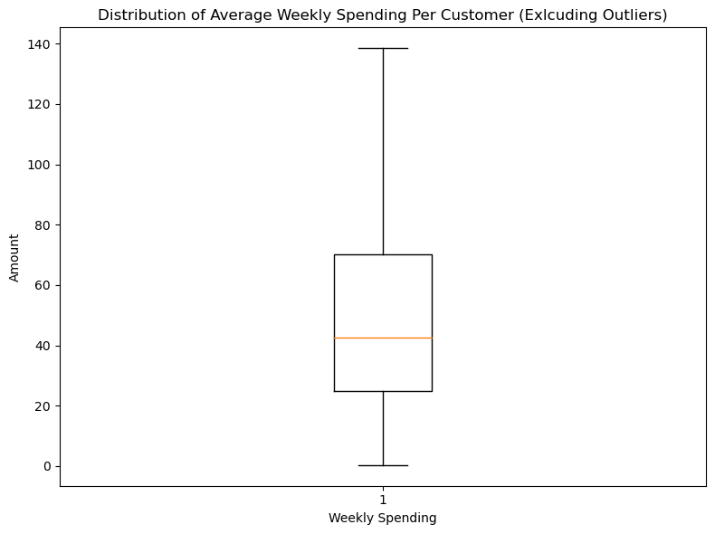

```python
# Create the boxplot for weekly spending spending
plt.figure(figsize=(8, 6))  # Set the figure size (optional)

# Assuming 'total_spending' is the column name in df_spend
plt.boxplot(df_spend['weekly_spending'], showfliers=False)


# Add labels and title
plt.xlabel('Weekly Spending')
plt.ylabel('Amount')
plt.title('Distribution of Average Weekly Spending Per Customer (Exlcuding Outliers)')

# Adjust margins and spacing
plt.tight_layout()

# export chart
plt.savefig('weekly_spending_per_customer_xoutliers.png')

plt.show()
```

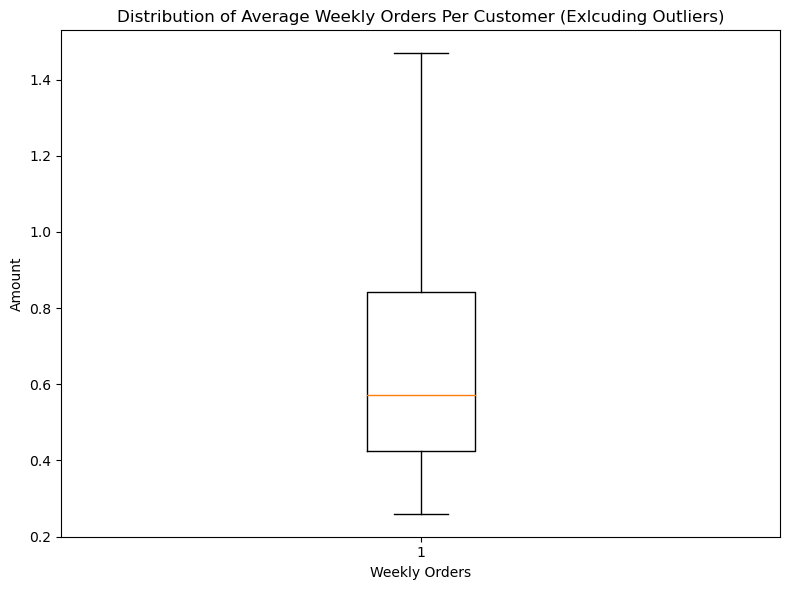

```python
# Create the boxplot for number of weekly orders
plt.figure(figsize=(8, 6))  # Set the figure size (optional)

# Assuming 'total_spending' is the column name in df_spend
plt.boxplot(df_spend['weekly_orders'], showfliers=False)


# Add labels and title
plt.xlabel('Weekly Orders')
plt.ylabel('Amount')
plt.title('Distribution of Average Weekly Orders Per Customer (Exlcuding Outliers)')

# Adjust margins and spacing
plt.tight_layout()

# export chart
plt.savefig('weekly_orders_per_customer_xoutliers.png')

plt.show()
```

Summary of statistics:

ORDERS PER WEEK

- Minimum: 0.26
- Mean: 0.71
- Max: 42

#### 7.2.3 Distribution of profiles across regions

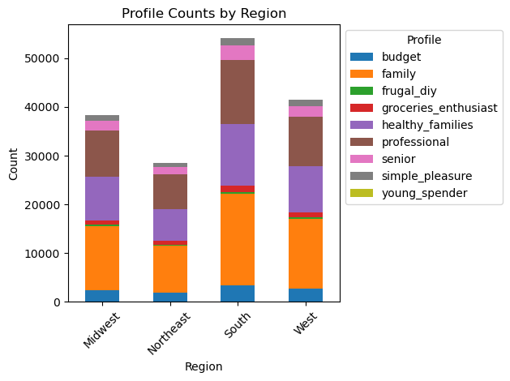

```python
# construct stacked bar chart of counts of profiles, subdivided by region

# Group the dataframe by 'region' and 'profile' columns and calculate the counts
grouped_df = df_spend.groupby(['region', 'profile']).size().unstack()

# Plotting the stacked bar chart
plt.figure(figsize=(12, 8))  # Adjust the figure size if needed
grouped_df.plot(kind='bar', stacked=True)
plt.title('Profile Counts by Region')
plt.xlabel('Region')
plt.ylabel('Count')
plt.xticks(rotation=45)  # Rotate the x-axis labels if needed
plt.legend(title='Profile', bbox_to_anchor=(1, 1))
# Adjust margins and spacing
plt.tight_layout()

# export chart
plt.savefig('profile_by_region.png')

plt.show()
```

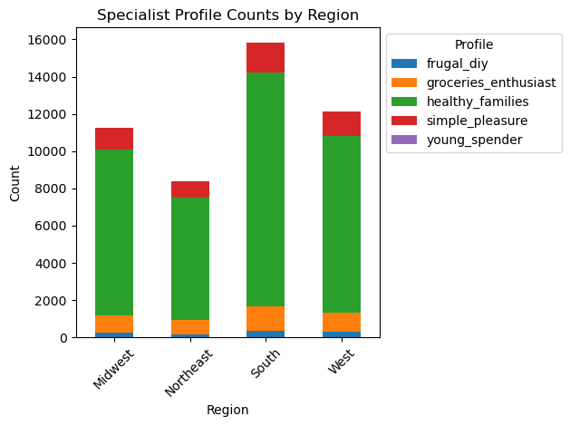

```python
# construct stacked bar chart of counts of specialist profiles, subdivided by region

# Filter the dataframe based on desired_profiles
special_profiles = ['frugal_diy','groceries_enthusiast','healthy_families','simple_pleasure','young_spender']
filtered_df = df_spend[df_spend['profile'].isin(special_profiles)]

# Group the filtered dataframe by 'region' and 'profile' columns and calculate the counts
grouped_df = filtered_df.groupby(['region', 'profile']).size().unstack()

# Plotting the stacked bar chart
plt.figure(figsize=(10, 6))  # Adjust the figure size if needed
grouped_df.plot(kind='bar', stacked=True)
plt.title('Specialist Profile Counts by Region')
plt.xlabel('Region')
plt.ylabel('Count')
plt.xticks(rotation=45)  # Rotate the x-axis labels if needed
plt.legend(title='Profile', bbox_to_anchor=(1, 1))
# Adjust margins and spacing
plt.tight_layout()

# export chart
plt.savefig('sig_profile_by_region.png')

plt.show()
```

#### 7.2.4 Spending behaviours by profiles

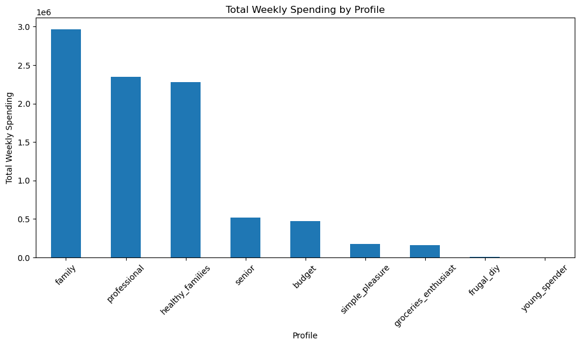

```python
# construct bar chart of weekly spending by profile

# Group the dataframe by 'profile' and calculate the sum of 'weekly_spending'
grouped_df = df_spend.groupby('profile')['weekly_spending'].sum()

# Sort the groups by total weekly spending in descending order
grouped_df = grouped_df.sort_values(ascending=False)

# Plotting the bar chart
plt.figure(figsize=(10, 6))  # Adjust the figure size if needed
grouped_df.plot(kind='bar')
plt.title('Total Weekly Spending by Profile')
plt.xlabel('Profile')
plt.ylabel('Total Weekly Spending')
plt.xticks(rotation=45)  # Rotate the x-axis labels if needed
# Adjust margins and spacing
plt.tight_layout()

# export chart
plt.savefig('weekly_spending_profile.png')

plt.show()
```

#### 7.2.5 Spending behaviours by regions

```python
# construct pivot table of total spending by region, including only the significant profiles
pt = df_spend[['region','profile','weekly_spending']][df_spend['profile'].isin(['family','healthy_families','professional'])].pivot_table(index='region', columns='profile', values='weekly_spending', aggfunc='sum')
pt
```

| profile region | family | healthy_families | professional |
| --- | --- | --- | --- |
| Midwest | 693063.887103 | 536700.722924 | 564497.125607 |
| Northeast | 523820.058538 | 394774.823737 | 407047.061311 |
| South | 991982.656455 | 764397.957333 | 776799.952186 |
| West | 757634.796007 | 582803.448110 | 601195.713840 |

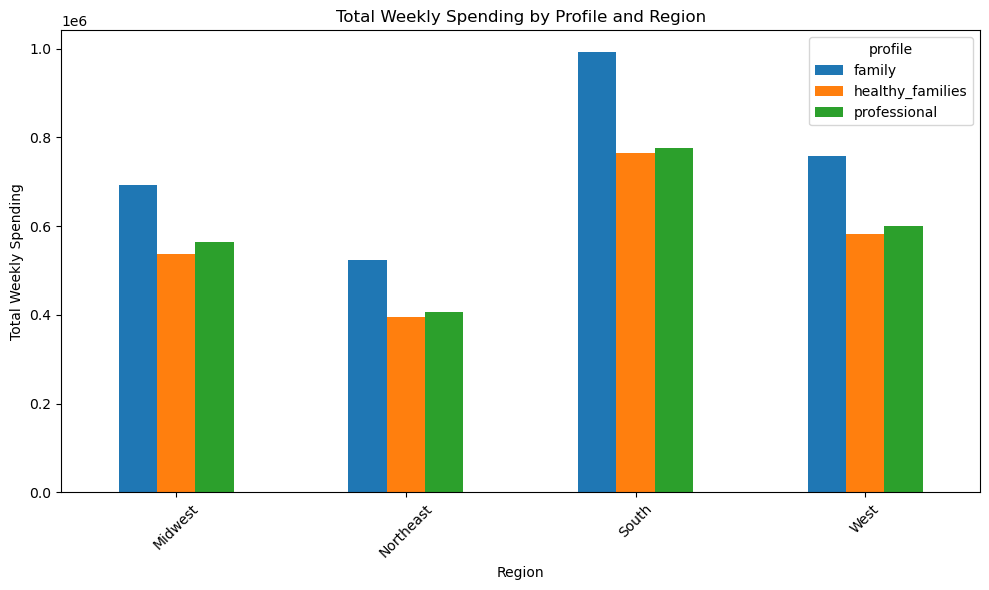

```python
# Plot the multiple bar chart
pt.plot(kind='bar', figsize=(10, 6))  # Adjust the figure size if needed

# Add labels and title
plt.xlabel('Region')
plt.xticks(rotation=45)
plt.ylabel('Total Weekly Spending')
plt.title('Total Weekly Spending by Profile and Region')

# Adjust margins and spacing
plt.tight_layout()

# export chart
plt.savefig('weekly_spending_by_sig_profile_region.png')

plt.show()
```

So the South has the greatest income. Each region follows the same trend that families spend the most, followed by professionals and healthy families (which are very similar). It must be noted that this regional difference is to be expected, given that the population of the South is significantly higher that the other regions. Henceforth, the analysis will discuss spending behaviour as an average, rather than a sum to address the population difference between regions.

## 8 Project Key Question Analysis

```python
# define significant profiles variable
sig_profiles = ['family','healthy_families','professionals']
```

### 8.1 What are the busiest days of the week and hours of the day?

#### 8.1.1 Days Of The Week: All Profiles

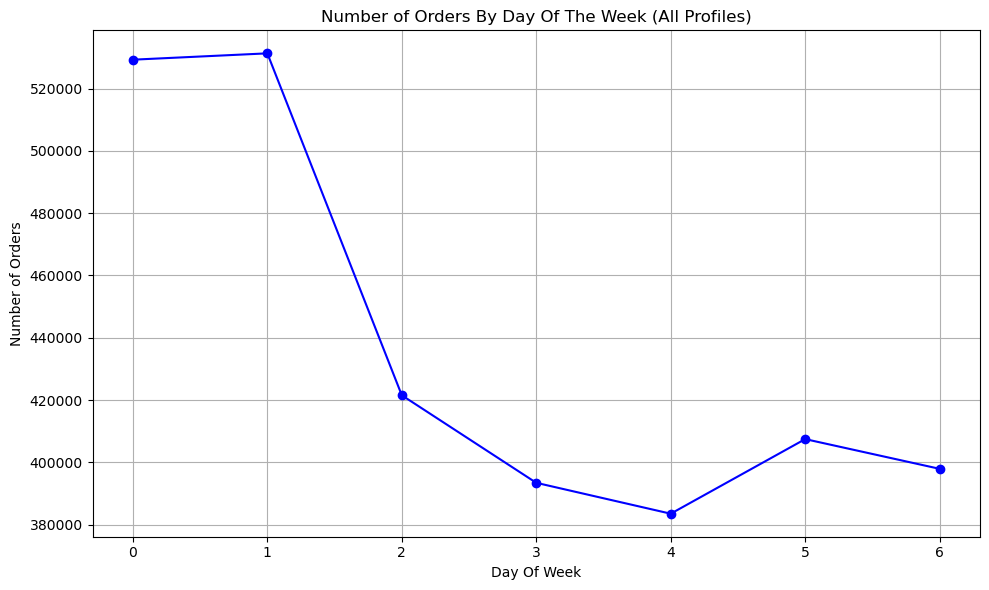

```python
# construct line graph of busiset hours of the day

# Group the DataFrame by 'hour_of_day' and calculate the count of unique 'order_id'
grouped_df = df_high.groupby('order_day_of_week')['order_id'].nunique()

# Plotting the line graph
plt.figure(figsize=(10, 6))  # Adjust the figure size if needed
grouped_df.plot(kind='line', marker='o', linestyle='-', color='blue')
plt.title('Number of Orders By Day Of The Week (All Profiles)')
plt.xlabel('Day Of Week')
plt.ylabel('Number of Orders')

# Adjust x-axis tick marks
ax = plt.gca()  # Get the current axes
ax.xaxis.set_major_locator(MaxNLocator(nbins=7))  # Set the number of major ticks to 7 (every 4th hour)

plt.xticks(rotation=0)  # Rotate the x-axis labels if needed
plt.grid(True)  # Add grid lines if desired

# Adjust margins and spacing
plt.tight_layout()

# export chart
plt.savefig('orders_by_day.png')

plt.show()
```

#### 8.1.2 Days Of The Week: Significant Profiles

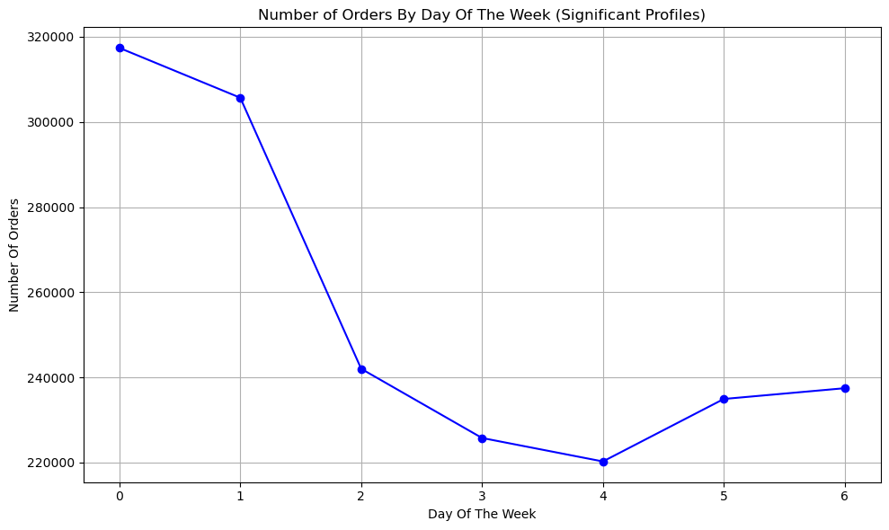

```python
# construct line graph for significant profiles

# Filter the DataFrame based on sig_profiles
filtered_df = df_high[df_high['profile'].isin(sig_profiles)]

# Group the filtered DataFrame by 'hour_of_day' and calculate the count of unique 'order_id'
grouped_df = filtered_df.groupby('order_day_of_week')['order_id'].nunique()

# Plotting the line graph
plt.figure(figsize=(10, 6))  # Adjust the figure size if needed
grouped_df.plot(kind='line', marker='o', linestyle='-', color='blue')
plt.title('Number of Orders By Day Of The Week (Significant Profiles)')
plt.xlabel('Day Of The Week')
plt.ylabel('Number Of Orders')

# Adjust x-axis tick marks
ax = plt.gca()  # Get the current axes
ax.xaxis.set_major_locator(MaxNLocator(nbins=7))  # Set the number of major ticks to 7 (every 4th hour)

plt.xticks(rotation=0)  # Rotate the x-axis labels if needed
plt.grid(True)  # Add grid lines if desired

# Adjust margins and spacing
plt.tight_layout()

# export chart
plt.savefig('orders_by_day_sigprofiles.png')

plt.show()
```

#### 8.1.4 Hours Of The Day: All profiles

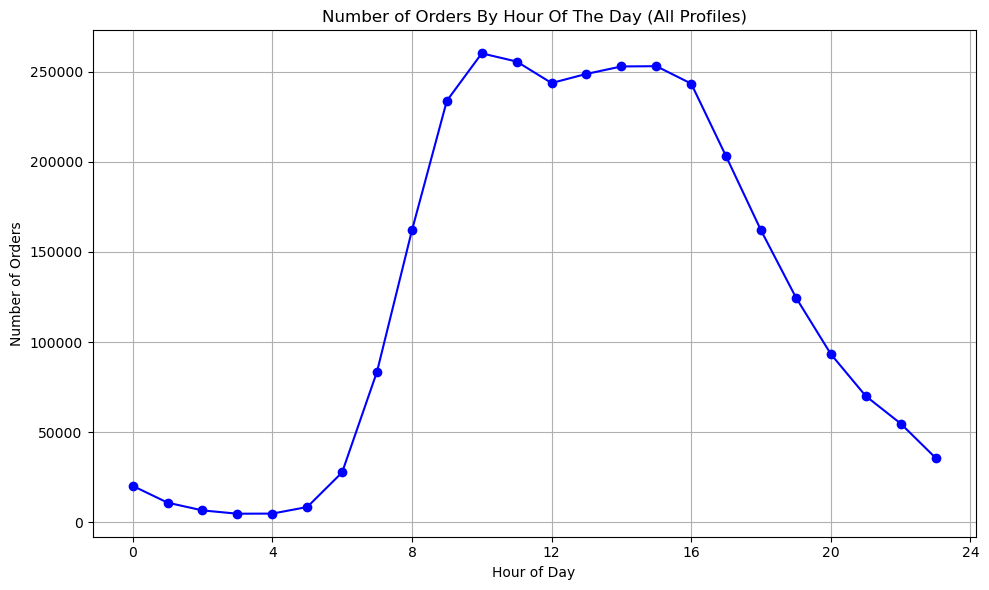

```python
# construct line graph of busiset hours of the day

# Group the DataFrame by 'hour_of_day' and calculate the count of unique 'order_id'
grouped_df = df_high.groupby('order_hour_of_day')['order_id'].nunique()

# Plotting the line graph
plt.figure(figsize=(10, 6))  # Adjust the figure size if needed
grouped_df.plot(kind='line', marker='o', linestyle='-', color='blue')
plt.title('Number of Orders By Hour Of The Day (All Profiles)')
plt.xlabel('Hour of Day')
plt.ylabel('Number of Orders')

# Adjust x-axis tick marks
ax = plt.gca()  # Get the current axes
ax.xaxis.set_major_locator(MaxNLocator(nbins=7))  # Set the number of major ticks to 7 (every 4th hour)

plt.xticks(rotation=0)  # Rotate the x-axis labels if needed
plt.grid(True)  # Add grid lines if desired

# Adjust margins and spacing
plt.tight_layout()

# export chart
plt.savefig('orders_by_hour.png')

plt.show()
```

#### 8.1.4 Hours Of The Day: Significant Profiles

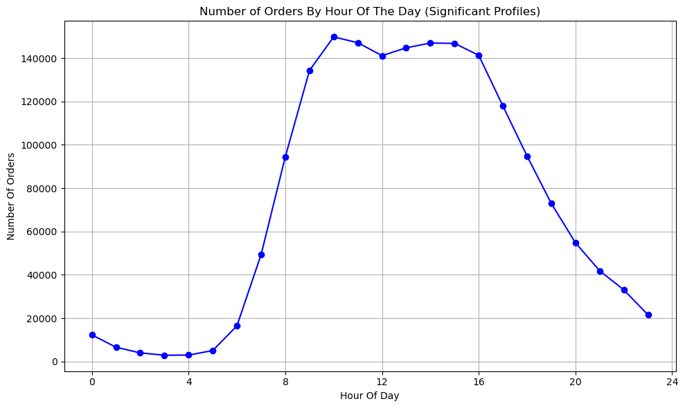

```python
# construct line graph for significant profiles

# Filter the DataFrame based on sig_profiles
filtered_df = df_high[df_high['profile'].isin(sig_profiles)]

# Group the filtered DataFrame by 'hour_of_day' and calculate the count of unique 'order_id'
grouped_df = filtered_df.groupby('order_hour_of_day')['order_id'].nunique()

# Plotting the line graph
plt.figure(figsize=(10, 6))  # Adjust the figure size if needed
grouped_df.plot(kind='line', marker='o', linestyle='-', color='blue')
plt.title('Number of Orders By Hour Of The Day (Significant Profiles)')
plt.xlabel('Hour Of Day')
plt.ylabel('Number Of Orders')

# Adjust x-axis tick marks
ax = plt.gca()  # Get the current axes
ax.xaxis.set_major_locator(MaxNLocator(nbins=7))  # Set the number of major ticks to 7 (every 4th hour)

plt.xticks(rotation=0)  # Rotate the x-axis labels if needed
plt.grid(True)  # Add grid lines if desired

# Adjust margins and spacing
plt.tight_layout()

# export chart
plt.savefig('orders_by_hour_sigprofiles.png')

plt.show()
```

#### 8.1.5 Conclusion

The busiest days of the week for orders are 0 and 1, that is Saturday and Sunday. There are much fewer orders during the week.

The busiest hours of the day are between 9.00-16.00. Orders grow until around 10.00, dip slightly at 12.00 (presumably when users have lunch), rise slightly again until 14.00 and begins to decline thereafter.

Essentially it demonstrates a bell curve, but with the expected peak truncated somewhat for lunch at 12-13.00.

There is no significant difference when filtering profiles, except for there are slightly fewer orders on a Sunday from the significant profiles.

### 8.2 Are there particular times of the day when people spend the most money?

#### 8.2.1 All profiles

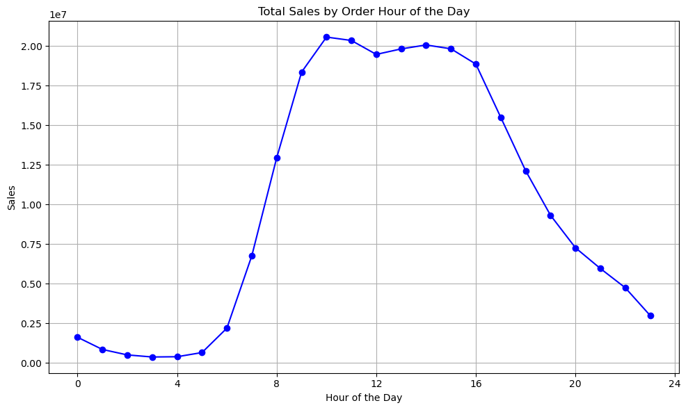

```python
# construct a line graph of total sales by hour of the day

# Group the DataFrame by 'order_hour_of_day' and calculate the sum of 'prices'
grouped_df = df_high.groupby('order_hour_of_day')['prices'].sum()

# Plotting the line graph
plt.figure(figsize=(10, 6))  # Adjust the figure size if needed
grouped_df.plot(kind='line', marker='o', linestyle='-', color='blue')
plt.title('Total Sales by Order Hour of the Day')
plt.xlabel('Hour of the Day')
plt.ylabel('Sales')

# Adjust x-axis tick marks
ax = plt.gca()  # Get the current axes
ax.xaxis.set_major_locator(MaxNLocator(nbins=7))  # Set the number of major ticks to 7 (every 4th hour)

plt.xticks(rotation=0)  # Rotate the x-axis labels if needed
plt.grid(True)  # Add grid lines if desired

# Adjust margins and spacing
plt.tight_layout()

# export chart
plt.savefig('sales_by_hour.png')

plt.show()
```

#### 8.2.2 Significant Profiles

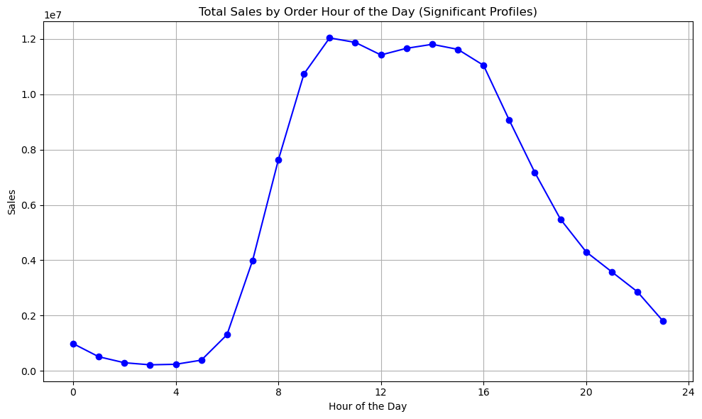

```python
# construct a line graph of total sales by hour of the day for significant profiles only

# Filter the DataFrame based on sig_profiles
filtered_df = df_high[df_high['profile'].isin(sig_profiles)]

# Group the DataFrame by 'order_hour_of_day' and calculate the sum of 'prices'
grouped_df = filtered_df.groupby('order_hour_of_day')['prices'].sum()

# Plotting the line graph
plt.figure(figsize=(10, 6))  # Adjust the figure size if needed
grouped_df.plot(kind='line', marker='o', linestyle='-', color='blue')
plt.title('Total Sales by Order Hour of the Day (Significant Profiles)')
plt.xlabel('Hour of the Day')
plt.ylabel('Sales')

# Adjust x-axis tick marks
ax = plt.gca()  # Get the current axes
ax.xaxis.set_major_locator(MaxNLocator(nbins=7))  # Set the number of major ticks to 7 (every 4th hour)

plt.xticks(rotation=0)  # Rotate the x-axis labels if needed
plt.grid(True)  # Add grid lines if desired

# Adjust margins and spacing
plt.tight_layout()

# export chart
plt.savefig('sales_by_hour_sigprofiles.png')

plt.show()
```

#### 8.2.3 Conclusion

The trend follows the same trend of the amount of orders by hour of the day, as you would expect. The greatest sales are between 9.00 and 16.00 with the same slight dip at around 12.00.

There is no significant difference when filtering by significant profiles.

### 8.3 Are there certain types of products that are more popular than others?

```python
df_high.columns
```

```
Index(['order_id', 'user_id', 'order_number', 'order_day_of_week',
       'order_hour_of_day', 'days_since_prior_order', 'product_id',
       'add_to_cart_order', 'reordered', 'product_name', 'aisle_id',
       'department_id', 'prices', 'sex', 'state', 'age', 'date_joined',
       'n_dependents', 'family_status', 'income', 'region', 'number_of_orders',
       'profile', 'total_spending', 'days_as_customer', 'weekly_spending',
       'weekly_orders', 'avg_order_frequency'],
      dtype='object')
```

#### 8.3.1 Top 10 Best Selling Products

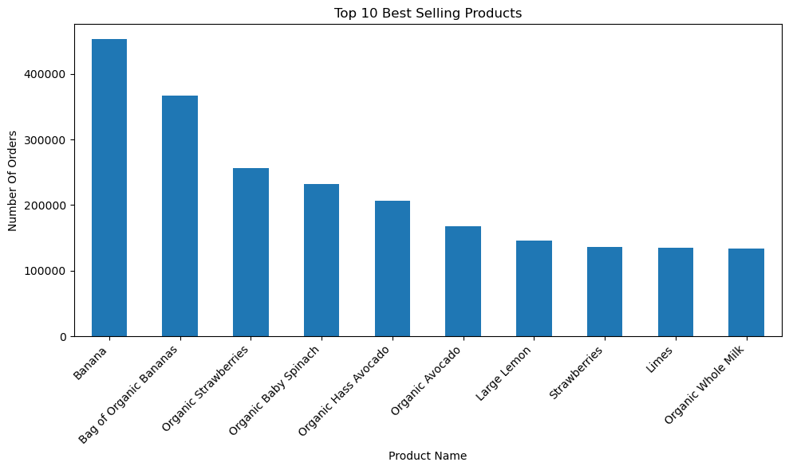

```python
# construct bar chart of the top 10 best selling products

# Group the DataFrame by 'product_name' and calculate the count
grouped_df = df_high['product_name'].value_counts().nlargest(10)

# Sort the values in descending order
grouped_df = grouped_df.sort_values(ascending=False)

# Plotting the bar chart
plt.figure(figsize=(10, 6))  # Adjust the figure size if needed
grouped_df.plot(kind='bar', align='center')  # Set align='center' to align the labels next to the bars
plt.title('Top 10 Best Selling Products')
plt.xlabel('Product Name')
plt.ylabel('Number Of Orders')
plt.xticks(rotation=45, ha='right')  # Rotate and align the x-axis labels
plt.grid(False)  # Add grid lines if desired
plt.tight_layout()  # Adjust the layout for better spacing

# Adjust margins and spacing
plt.tight_layout()

# export chart
plt.savefig('bestselling_products.png')

plt.show()
```

#### 8.3.2 Top 10 Best Selling Departments

```python
# add department names to df_high
df_high = df_high.merge(df_dept[['department_id','department']], on='department_id', how='left')
```

```python
df_high.columns
```

```
Index(['order_id', 'user_id', 'order_number', 'order_day_of_week',
       'order_hour_of_day', 'days_since_prior_order', 'product_id',
       'add_to_cart_order', 'reordered', 'product_name', 'aisle_id',
       'department_id', 'prices', 'sex', 'state', 'age', 'date_joined',
       'n_dependents', 'family_status', 'income', 'region', 'number_of_orders',
       'profile', 'total_spending', 'days_as_customer', 'weekly_spending',
       'weekly_orders', 'avg_order_frequency', 'department'],
      dtype='object')
```

```python
# check merge
df_high[['department_id','department']].value_counts()
```

```
department_id  department
4              produce          9079274
16             dairy            5191823
19             snacks           2766406
7              beverages        2571934
1              frozen           2123341
13             pantry           1782903
3              bakery           1125026
15             canned goods     1012074
20             deli             1003834
9              dry goods         822136
17             household         699857
14             breakfast         677073
12             meat seafood      674785
11             personal care     424362
18             babies            410392
6              international     255991
5              alcohol           144627
8              pets               93065
21             missing            64768
2              other              34411
10             bulk               33451
dtype: int64
```

```python
df_high[['department_id','department']].value_counts().sum()
```

```
30991533
```

```python
df_high.shape
```

```
(30991533, 29)
```

```python
df_high[['department_id','department']].isnull().sum()
```

```
department_id    0
department       0
dtype: int64
```

Merge appears to have worked correctly.

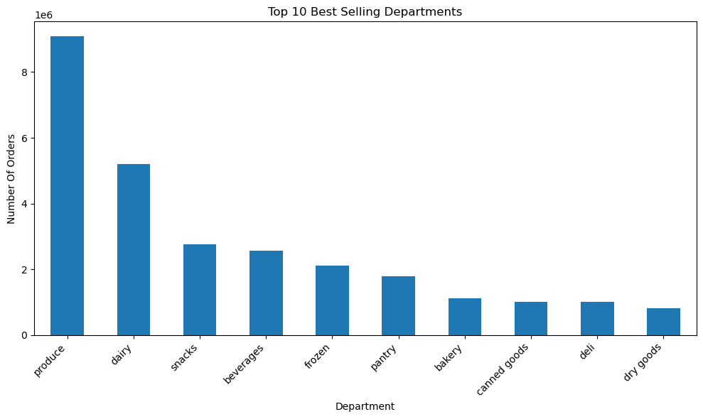

```python
# construct bar chart of the top 10 best selling departments

# Group the DataFrame by 'product_name' and calculate the count
grouped_df = df_high['department'].value_counts().nlargest(10)

# Sort the values in descending order
grouped_df = grouped_df.sort_values(ascending=False)

# Plotting the bar chart
plt.figure(figsize=(10, 6))  # Adjust the figure size if needed
grouped_df.plot(kind='bar', align='center')  # Set align='center' to align the labels next to the bars
plt.title('Top 10 Best Selling Departments')
plt.xlabel('Department')
plt.ylabel('Number Of Orders')
plt.xticks(rotation=45, ha='right')  # Rotate and align the x-axis labels
plt.grid(False)  # Add grid lines if desired
plt.tight_layout()  # Adjust the layout for better spacing

# Adjust margins and spacing
plt.tight_layout()

# export chart
plt.savefig('best_selling_departments.png')

plt.show()
```

#### 8.3.3 Conclusion

Produce is the standout best selling department, which meets expectations since once of the highest buying profiles is healthy families. The top 10 best selling products are also all produce products, except for organic whole milk. Dairy is the next best selling department, significantly higher than all other departments.

### 8.4 Customer behaviour: how often do customers return to Instacart?

#### 8.4.1 How many orders per week do users make?

First constructing a histogram for this data returns unusual/unhelpful visualisation. Looking the summary statistics below, we can see why. The vast majority of the statistics are between 0.26 and 0.84, but then there are extreme values, such as 42.

Checking this for errors showed that there are no errors, however for example, user 138747 made their first ever order and then made 5 further orders within the next day. This means he/she made 6 orders in the space of a day, which averages out to 42 orders a week.

Since this is unhelpful for our analysis, we will exclude users that fit the mean +- 2 standard deviations outlier rule (users with weekly_orders outside the range 0-1.725526 will be excluded).

```python
df_spend['weekly_orders'].describe()
```

```
count    162632.000000
mean          0.710733
std           0.507387
min           0.260135
25%           0.424242
50%           0.571429
75%           0.842105
max          42.000000
Name: weekly_orders, dtype: float64
```

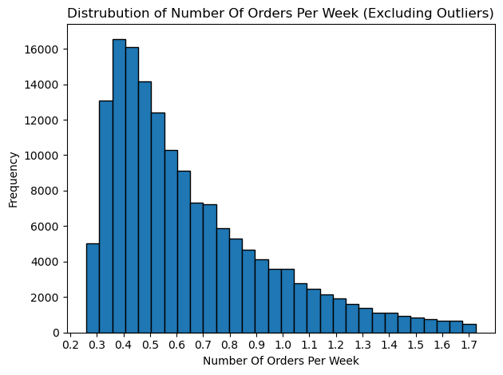

```python
# construct histogram of average number of orders per week

# Filter the weekly_orders column to exclude values greater than 1.725526
filtered_weekly_orders = df_spend[df_spend['weekly_orders'] <= 1.725526]['weekly_orders']

# Plot the histogram
plt.hist(filtered_weekly_orders, bins=30, edgecolor='black')

# Customize the x-axis ticks to appear every 0.1
plt.xticks(np.arange(0.2, 1.8, 0.1))

# Customize the plot
plt.xlabel('Number Of Orders Per Week')
plt.ylabel('Frequency')
plt.title('Distrubution of Number Of Orders Per Week (Excluding Outliers)')

# Adjust margins and spacing
plt.tight_layout()

# export chart
plt.savefig('orders_per_week.png')

plt.show()
```

#### 8.4.2 How frequently do customers return on average?

```python
# view summary statistics
df_spend['avg_order_frequency'].describe()
```

```
count    162632.000000
mean          1.794000
std           0.753376
min           0.023810
25%           1.187500
50%           1.750000
75%           2.357143
max           3.844156
Name: avg_order_frequency, dtype: float64
```

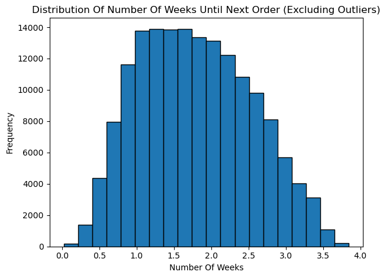

```python
# construct histogram of average number of weeks per return to instacart

# Filter the weekly_orders column to exclude values greater than 1.725526
filtered_weekly_orders = df_spend[df_spend['avg_order_frequency'] <= 3.844156]['avg_order_frequency']

# Plot the histogram
plt.hist(filtered_weekly_orders, bins=20, edgecolor='black')

# Customize the plot
plt.xlabel('Number Of Weeks')
plt.ylabel('Frequency')
plt.title('Distribution Of Number Of Weeks Until Next Order (Excluding Outliers)')

# Adjust margins and spacing
plt.tight_layout()

# export chart
plt.savefig('weeks_until_next_order.png')

plt.show()
```

#### 8.4.3 Conclusion

There are two ways here to consider usage frequency.

By considering the number of weeks until users make their next order:

- On average, users make their next order after 1.75 weeks and the majority of users make their next order within 1-2.5 weeks.

### 8.5 Customer behaviour: are there differences in ordering habits based on a customer’s loyalty status?

What does the client consider to be loyal?

Frequency of orders? May not represent amount spent

### 8.6 Customer behaviour: are there differences in ordering habits based on a customer’s region?

#### 8.6.1 Are there differences in types of products bought by region?

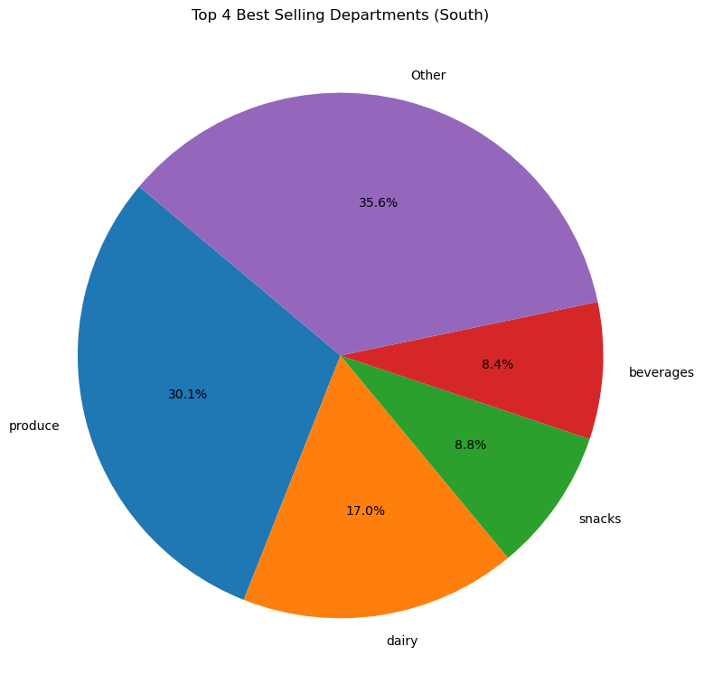

```python
# Filter data for the South region
south_region_data = df_high[df_high['region'] == 'South']

# Calculate the total weekly orders for each department
department_orders = south_region_data.groupby('department')['weekly_orders'].sum().reset_index()

# Sort the departments based on the total weekly orders in descending order
department_orders_sorted = department_orders.sort_values(by='weekly_orders', ascending=False)

# Get the top four most ordered departments and their weekly_orders
top_four_departments = department_orders_sorted.head(4)

# Calculate the total weekly orders for the remaining departments as 'Other'
remaining_orders = department_orders_sorted.iloc[4:]
other_orders = pd.DataFrame({'department': ['Other'], 'weekly_orders': [remaining_orders['weekly_orders'].sum()]})

# Combine the top four departments and 'Other'
departments_combined = pd.concat([top_four_departments, other_orders])

# Create the pie chart
plt.figure(figsize=(8, 8))
plt.pie(departments_combined['weekly_orders'], labels=departments_combined['department'], autopct='%1.1f%%', startangle=140)

# Add a title to the pie chart
plt.title('Top 4 Best Selling Departments (South)')

# Adjust margins and spacing
plt.tight_layout()

# export chart
plt.savefig('best_selling_departments_south.png')

plt.show()
```

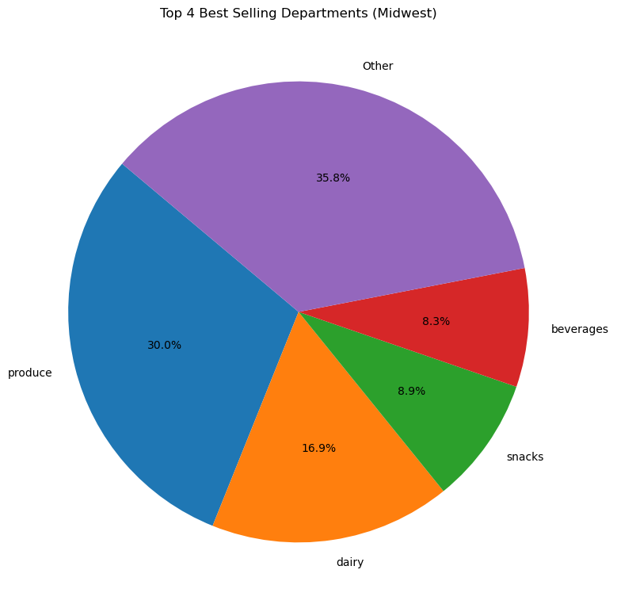

```python
# Filter data for the Midwest region
south_region_data = df_high[df_high['region'] == 'Midwest']

# Calculate the total weekly orders for each department
department_orders = south_region_data.groupby('department')['weekly_orders'].sum().reset_index()

# Sort the departments based on the total weekly orders in descending order
department_orders_sorted = department_orders.sort_values(by='weekly_orders', ascending=False)

# Get the top four most ordered departments and their weekly_orders
top_four_departments = department_orders_sorted.head(4)

# Calculate the total weekly orders for the remaining departments as 'Other'
remaining_orders = department_orders_sorted.iloc[4:]
other_orders = pd.DataFrame({'department': ['Other'], 'weekly_orders': [remaining_orders['weekly_orders'].sum()]})

# Combine the top four departments and 'Other'
departments_combined = pd.concat([top_four_departments, other_orders])

# Create the pie chart
plt.figure(figsize=(8, 8))
plt.pie(departments_combined['weekly_orders'], labels=departments_combined['department'], autopct='%1.1f%%', startangle=140)

# Add a title to the pie chart
plt.title('Top 4 Best Selling Departments (Midwest)')

# Adjust margins and spacing
plt.tight_layout()

# export chart
plt.savefig('best_selling_departments_midwest.png')

plt.show()
```

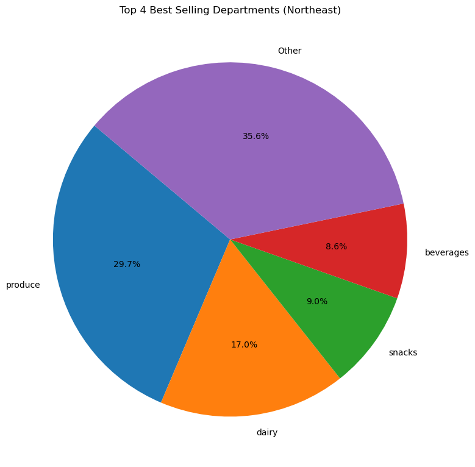

```python
# Filter data for the Northeast region
south_region_data = df_high[df_high['region'] == 'Northeast']

# Calculate the total weekly orders for each department
department_orders = south_region_data.groupby('department')['weekly_orders'].sum().reset_index()

# Sort the departments based on the total weekly orders in descending order
department_orders_sorted = department_orders.sort_values(by='weekly_orders', ascending=False)

# Get the top four most ordered departments and their weekly_orders
top_four_departments = department_orders_sorted.head(4)

# Calculate the total weekly orders for the remaining departments as 'Other'
remaining_orders = department_orders_sorted.iloc[4:]
other_orders = pd.DataFrame({'department': ['Other'], 'weekly_orders': [remaining_orders['weekly_orders'].sum()]})

# Combine the top four departments and 'Other'
departments_combined = pd.concat([top_four_departments, other_orders])

# Create the pie chart
plt.figure(figsize=(8, 8))
plt.pie(departments_combined['weekly_orders'], labels=departments_combined['department'], autopct='%1.1f%%', startangle=140)

# Add a title to the pie chart
plt.title('Top 4 Best Selling Departments (Northeast)')

# Adjust margins and spacing
plt.tight_layout()

# export chart
plt.savefig('best_selling_departments_northeast.png')

plt.show()
```

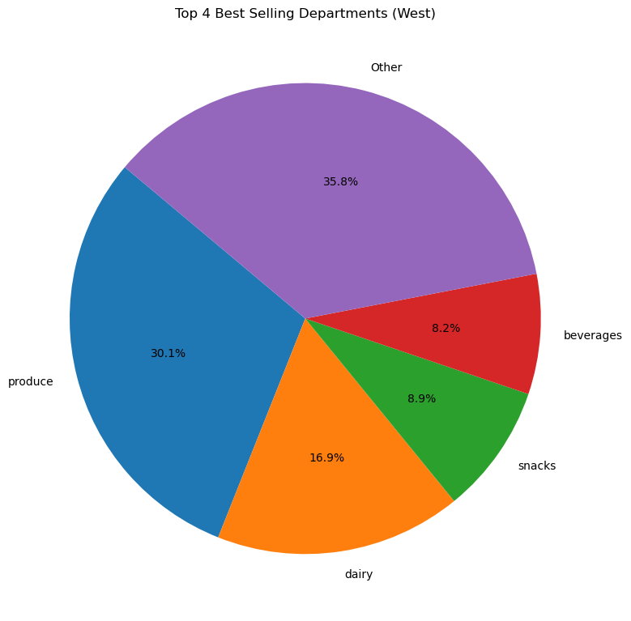

```python
# Filter data for the West region
south_region_data = df_high[df_high['region'] == 'West']

# Calculate the total weekly orders for each department
department_orders = south_region_data.groupby('department')['weekly_orders'].sum().reset_index()

# Sort the departments based on the total weekly orders in descending order
department_orders_sorted = department_orders.sort_values(by='weekly_orders', ascending=False)

# Get the top four most ordered departments and their weekly_orders
top_four_departments = department_orders_sorted.head(4)

# Calculate the total weekly orders for the remaining departments as 'Other'
remaining_orders = department_orders_sorted.iloc[4:]
other_orders = pd.DataFrame({'department': ['Other'], 'weekly_orders': [remaining_orders['weekly_orders'].sum()]})

# Combine the top four departments and 'Other'
departments_combined = pd.concat([top_four_departments, other_orders])

# Create the pie chart
plt.figure(figsize=(8, 8))
plt.pie(departments_combined['weekly_orders'], labels=departments_combined['department'], autopct='%1.1f%%', startangle=140)

# Add a title to the pie chart
plt.title('Top 4 Best Selling Departments (West)')

# Adjust margins and spacing
plt.tight_layout()

# export chart
plt.savefig('best_selling_departments_west.png')

plt.show()
```

All of the pie charts show very similar distribution of types of products bought. For all regions, the best selling product types are produce, dairy, snacks, beverages, other, with near identical proportions.

There is no regional difference in product types sold.

#### 8.6.2 Is there a regional difference in spending and order frequency?

```python
# find summary of average weekly number of orders and weekly spending
pd.pivot_table(df_spend, index='region', values=['weekly_spending', 'weekly_orders'], aggfunc='mean')
```

| region | weekly_orders | weekly_spending |
| --- | --- | --- |
| Midwest | 0.705278 | 54.782461 |
| Northeast | 0.713523 | 54.962987 |
| South | 0.710085 | 54.873296 |
| West | 0.714701 | 55.254356 |

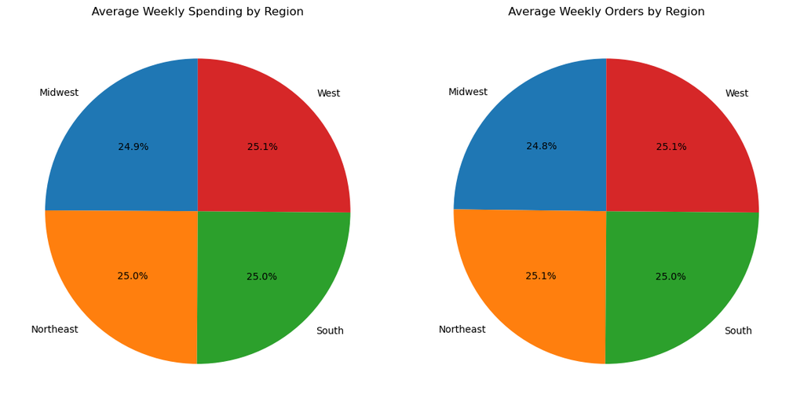

```python
# Calculate average weekly spending by region
avg_weekly_spending = df_spend.groupby('region')['weekly_spending'].mean()

# Calculate average weekly orders by region
avg_weekly_orders = df_spend.groupby('region')['weekly_orders'].mean()

# Create a 1x2 grid of subplots
fig, axes = plt.subplots(nrows=1, ncols=2, figsize=(12, 6))

# Plot the first pie chart (average weekly spending) in the left subplot
axes[0].pie(avg_weekly_spending, labels=avg_weekly_spending.index, autopct='%1.1f%%', startangle=90)
axes[0].set_title('Average Weekly Spending by Region')

# Plot the second pie chart (average weekly orders) in the right subplot
axes[1].pie(avg_weekly_orders, labels=avg_weekly_orders.index, autopct='%1.1f%%', startangle=90)
axes[1].set_title('Average Weekly Orders by Region')

# Adjust spacing between subplots
plt.tight_layout()

# Adjust margins and spacing
plt.tight_layout()

# export chart
plt.savefig('regional_weekly_spending_orders.png')

plt.show()
```

```python
# Conduct t-test on the upper extreme weekly_spending mean (West)

# Let's first filter the DataFrame to get the data for the West region
data = df_spend[df_spend['region'] == 'West']['weekly_spending']

# Now, calculate the mean and standard deviation for the West region data
mean = data.mean()
std = data.std()

# Calculate the mean and standard deviation for the entire dataset
overall_mean = df_spend['weekly_spending'].mean()
overall_std = df_spend['weekly_spending'].std()

# Perform the two-sample t-test
t_stat, p_value = ttest_ind(data, df_spend['weekly_spending'], equal_var=False)

# Print the results
print(f"West Region Mean: {mean:.2f}")
print(f"Overall Mean: {overall_mean:.2f}")
print(f"t-statistic: {t_stat:.2f}")
print(f"P-value: {p_value:.5f}")

# Check if the p-value is less than the significance level (e.g., 0.05) to determine significance
alpha = 0.05
if p_value < alpha:
    print("The mean weekly spending for the West region is significantly different from the overall mean.")
else:
    print("There is no significant difference in the mean weekly spending for the West region.")
```

```
West Region Mean: 55.25
Overall Mean: 54.96
t-statistic: 1.04
P-value: 0.29671
There is no significant difference in the mean weekly spending for the West region.
```

```python
# Conduct t-test on the lower extreme weekly_spending mean (Midwest)

# Let's first filter the DataFrame to get the data for the Midwest region
data = df_spend[df_spend['region'] == 'Midwest']['weekly_spending']

# Now, calculate the mean and standard deviation for the West region data
mean = data.mean()
std = data.std()

# Calculate the mean and standard deviation for the entire dataset
overall_mean = df_spend['weekly_spending'].mean()
overall_std = df_spend['weekly_spending'].std()

# Perform the two-sample t-test
t_stat, p_value = ttest_ind(data, df_spend['weekly_spending'], equal_var=False)

# Print the results
print(f"Midwest Region Mean: {mean:.2f}")
print(f"Overall Mean: {overall_mean:.2f}")
print(f"t-statistic: {t_stat:.2f}")
print(f"P-value: {p_value:.5f}")

# Check if the p-value is less than the significance level (e.g., 0.05) to determine significance
alpha = 0.05
if p_value < alpha:
    print("The mean weekly spending for the Midwest region is significantly different from the overall mean.")
else:
    print("There is no significant difference in the mean weekly spending for the Midwest region.")
```

```
Midwest Region Mean: 54.78
Overall Mean: 54.96
t-statistic: -0.67
P-value: 0.50490
There is no significant difference in the mean weekly spending for the Midwest region.
```

#### 8.6.3 Conclusion

The pie charts on department sales show that there are no regional differences.

The pie charts show that proportionally the regional weekly spending and weekly number of orders are near identical. The t-tests confirm that they are not statistically, significantly different.

There is no significant regional difference in spending habits.

### 8.7 Customer behaviour: is there a connection between age and family status in terms of ordering habits?

```python
# add user_flags dataframe to df_spend to analyse specific flags
user_flags = pd.read_csv(os.path.join(path,'Prepared Data','user_flags.csv'), index_col=0)
```

```python
# merge dataframes
df_spend = df_spend.merge(user_flags[['user_id','age_flag','income_flag','regularity_flag','groceries_flag','spending_flag','has_dependents']],on='user_id', how = 'left')
```

#### 8.7.1 Weekly spending by age and dependents status

```python
# view pivot table of average weekly spending per customer
pivot_table = df_spend.pivot_table(index='age_flag', columns='has_dependents', values='weekly_spending', aggfunc='mean')
pivot_table
```

| has_dependents age_flag | False | True |
| --- | --- | --- |
| adult | 54.954558 | 54.883045 |
| senior | 54.982576 | 54.974669 |
| young_adult | 54.697132 | 55.177878 |

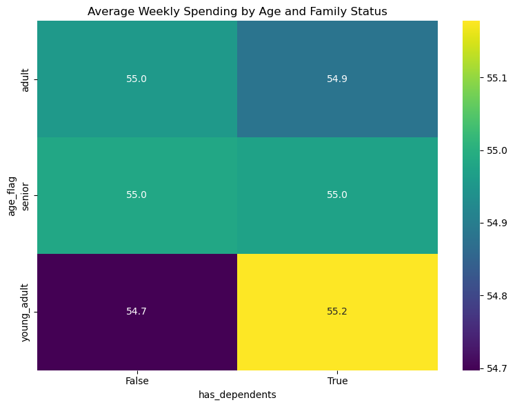

```python
# Create a color gradient using seaborn's heatmap
plt.figure(figsize=(8, 6))  # Adjust the figure size if needed

# Use the 'coolwarm' colormap for a nice gradient effect
sns.heatmap(pivot_table, annot=True, cmap='viridis', fmt=".1f", cbar=True)

# Add a title
plt.title('Average Weekly Spending by Age and Family Status')

# Adjust margins and spacing
plt.tight_layout()

# export chart
plt.savefig('weekly_spending_age_family.png')

plt.show()
```

From this table, we can see that the young_adults have the most different weekly spending habits, either with dependents or without dependents. However, are they significantly different from the overall mean?

```python
# test whether the young_adults with dependents (upper extreme value) is significantly different from the overall mean

data = df_spend[['age_flag','has_dependents','weekly_spending']]

# Filter data for young_adults with has_dependents=True
young_adults_with_dependents = data[(data['age_flag'] == 'young_adult') & (data['has_dependents'] == True)]

# Calculate the mean for the young adults with dependents
mean_young_adults = young_adults_with_dependents['weekly_spending'].mean()

# Calculate the mean for the entire dataset
overall_mean = data['weekly_spending'].mean()

# Perform the one-sample t-test
t_stat, p_value = ttest_1samp(young_adults_with_dependents['weekly_spending'], overall_mean)

# Print the results
print(f"Sample Mean (Young Adults with Dependents): {mean_young_adults:.2f}")
print(f"Overall Mean: {overall_mean:.2f}")
print(f"t-statistic: {t_stat:.2f}")
print(f"P-value: {p_value:.5f}")

# Check if the p-value is less than the significance level (e.g., 0.05) to determine significance
alpha = 0.05
if p_value < alpha:
    print("The average weekly spending for Young Adults with Dependents is significantly different from the overall mean.")
else:
    print("There is no significant difference in the average weekly spending for Young Adults with Dependents.")
```

```
Sample Mean (Young Adults with Dependents): 55.18
Overall Mean: 54.96
t-statistic: 0.82
P-value: 0.41299
There is no significant difference in the average weekly spending for Young Adults with Dependents.
```

```python
# test whether the young_adults without dependents (lower extreme value) is significantly different from the overall mean

data = df_spend[['age_flag','has_dependents','weekly_spending']]

# Filter data for young_adults with has_dependents=True
young_adults_without_dependents = data[(data['age_flag'] == 'young_adult') & (data['has_dependents'] == False)]

# Calculate the mean for the young adults with dependents
mean_young_adults = young_adults_without_dependents['weekly_spending'].mean()

# Calculate the mean for the entire dataset
overall_mean = data['weekly_spending'].mean()

# Perform the one-sample t-test
t_stat, p_value = ttest_1samp(young_adults_without_dependents['weekly_spending'], overall_mean)

# Print the results
print(f"Sample Mean (Young Adults without Dependents): {mean_young_adults:.2f}")
print(f"Overall Mean: {overall_mean:.2f}")
print(f"t-statistic: {t_stat:.2f}")
print(f"P-value: {p_value:.5f}")

# Check if the p-value is less than the significance level (e.g., 0.05) to determine significance
alpha = 0.05
if p_value < alpha:
    print("The average weekly spending for Young Adults without Dependents is significantly different from the overall mean.")
else:
    print("There is no significant difference in the average weekly spending for Young Adults without Dependents.")
```

```
Sample Mean (Young Adults without Dependents): 54.70
Overall Mean: 54.96
t-statistic: -0.55
P-value: 0.58298
There is no significant difference in the average weekly spending for Young Adults without Dependents.
```

There is no sigificant difference in weekly amounts spent by age or family status.

#### 8.7.2 Number of orders per week by age and family status

```python
# view pivot table of average orders per week by customer
pivot_table = df_spend.pivot_table(index='age_flag', columns='has_dependents', values='weekly_orders', aggfunc='mean')
pivot_table
```

| has_dependents age_flag | False | True |
| --- | --- | --- |
| adult | 0.714896 | 0.709480 |
| senior | 0.710284 | 0.711549 |
| young_adult | 0.707130 | 0.711081 |

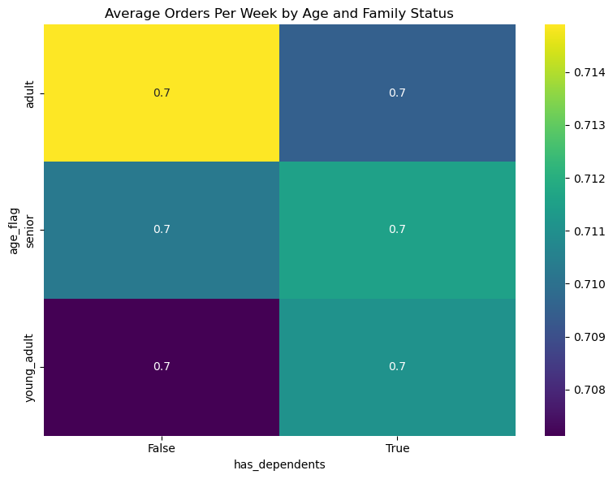

```python
# Create a color gradient pivot table using seaborn's heatmap
plt.figure(figsize=(8, 6))

# Use the 'viridis' colormap for a nice gradient effect
sns.heatmap(pivot_table, annot=True, cmap='viridis', fmt=".1f", cbar=True)

# Add a title
plt.title('Average Orders Per Week by Age and Family Status')

# Adjust margins and spacing
plt.tight_layout()

# export chart
plt.savefig('weekly_orders_age_family.png')

plt.show()
```

From this table, we can see that the young_adults and adults without dependents have the most different number of weekly orders. However, are they significantly different from the overall mean?

```python
# test whether the adults without dependents (upper extreme value) is significantly different from the overall mean

data = df_spend[['age_flag','has_dependents','weekly_orders']]

# Filter data for young_adults with has_dependents=True
adults_without_dependents = data[(data['age_flag'] == 'adult') & (data['has_dependents'] == False)]

# Calculate the mean for the young adults with dependents
mean_adults = adults_without_dependents['weekly_orders'].mean()

# Calculate the mean for the entire dataset
overall_mean = data['weekly_orders'].mean()

# Perform the one-sample t-test
t_stat, p_value = ttest_1samp(adults_without_dependents['weekly_orders'], overall_mean)

# Print the results
print(f"Sample Mean (Adults without Dependents): {mean_adults:.2f}")
print(f"Overall Mean: {overall_mean:.2f}")
print(f"t-statistic: {t_stat:.2f}")
print(f"P-value: {p_value:.5f}")

# Check if the p-value is less than the significance level (e.g., 0.05) to determine significance
alpha = 0.05
if p_value < alpha:
    print("The average weekly spending for Adults without Dependents is significantly different from the overall mean.")
else:
    print("There is no significant difference in the average weekly spending for Adults without Dependents.")
```

```
Sample Mean (Adults without Dependents): 0.71
Overall Mean: 0.71
t-statistic: 1.01
P-value: 0.31124
There is no significant difference in the average weekly spending for Adults without Dependents.
```

```python
# test whether the young adults without dependents (lower extreme value) is significantly different from the overall mean

data = df_spend[['age_flag','has_dependents','weekly_orders']]

# Filter data for young_adults with has_dependents=True
young_adults_without_dependents = data[(data['age_flag'] == 'young_adult') & (data['has_dependents'] == False)]

# Calculate the mean for the young adults with dependents
mean_young_adults = young_adults_without_dependents['weekly_orders'].mean()

# Calculate the mean for the entire dataset
overall_mean = data['weekly_orders'].mean()

# Perform the one-sample t-test
t_stat, p_value = ttest_1samp(young_adults_without_dependents['weekly_orders'], overall_mean)

# Print the results
print(f"Sample Mean (Young Adults without Dependents): {mean_adults:.2f}")
print(f"Overall Mean: {overall_mean:.2f}")
print(f"t-statistic: {t_stat:.2f}")
print(f"P-value: {p_value:.5f}")

# Check if the p-value is less than the significance level (e.g., 0.05) to determine significance
alpha = 0.05
if p_value < alpha:
    print("The average weekly spending for Young Adults without Dependents is significantly different from the overall mean.")
else:
    print("There is no significant difference in the average weekly spending for Young Adults without Dependents.")
```

```
Sample Mean (Young Adults without Dependents): 0.71
Overall Mean: 0.71
t-statistic: -0.66
P-value: 0.51166
There is no significant difference in the average weekly spending for Young Adults without Dependents.
```

There is no sigificant difference in number of weekly orders by age or family status.

## 9 Analysis Conclusion & Summary

### 9.1 General Spending

Average Orders Per Week Per Customer

- Minimum: 0.26
- Mean: 0.71
- Max: 42

The greatest income is from the South, followed by the West and Midwest (with similar income) and the Northeast with lowest income. This follows the general US population trends by region.

See section 7.2.2 for more details.

### 9.2 Busiest days of the week and hours of the day

The busiest days of the week for orders are Saturday and Sunday. There are much fewer orders during the week.

The busiest hours of the day are between 9.00-16.00. Orders grow until around 10.00, dip slightly at 12.00 (presumably when users have lunch), rise slightly again until 14.00 and begins to decline thereafter.

Essentially it demonstrates a bell curve, but with the expected peak truncated somewhat for lunch at 12-13.00.

There is no significant difference when filtering profiles, except for there are slightly fewer orders on a Sunday from the significant profiles.

See sections 8.1 and 8.2 for more detail.

### 9.3 Profiling

Customers have been profiled as one of the following and so that no one customer has more than one profile type: Specialist profiles

- Health Families
- Grocery Enthusiasts
- Simple Pleasures
- Young Spender
- Frugal DIY

Non-Specialist profiles

- Professional
- Family
- Budget
- Senior

The vast majority of customers can be profiled as Families, Healthy Families and Professionals. These profile were henceforth referred to as "significant profiles" in the analysis. The distribution of customer profiles across different regions is much the same and there are more of each in the South and less in the Northeast. This is not unusual and meets expectations, as it follows the general US population distribution by region.

See section 6.7 for more details.

### 9.4 Best selling products

The standout, best selling product departments are produce and dairy, followed by snacks and beverages. This indicates a general profile for Instacart customers of healthy shopping and eating, which correlates with the Healthy Families profile being one of the most significant profiles. The spending habits across regions are not different, that is each region has the same distribution of sales by department. Raw sales are different, but this is accounted for by differing amounts of customers per region, following the population distribution of the US. Of the 10 best selling products, 9 are produce (mostly fruit) and 1 is a dairy product.

See section 8.3 for more details.

### 9.5 How often customers return to Instacart

As per the requirements of the project, all customers with fewer than 5 orders were excluded from the analysis.

There are two ways here to consider usage frequency.

By considering the number of weeks until users make their next order:

- On average, users make their next order after 1.75 weeks and the majority of users make their next order within 1-2.5 weeks.

See section 8.4 for more details

### 9.6 Regional differences in spending habits

The pie charts on department sales show that there are no regional differences.

The pie charts show that proportionally the regional, average weekly spending and weekly number of orders are near identical. The t-tests confirm that they are not statistically, significantly different.

There is no significant regional difference in spending habits.

See section 8.6 for more details.

### 9.7 Differences in spending habits by age and family status

Analysis on average number of orders per week and weekly spending by age group and whether the user has dependents showed that: there are no significant differences in spending habits age and family status. T-tests confirmed that the averages of each group were not statistically, significantly different.

Age and family status has no effect on spending habits.

See section 8.7 for more details.